# **- SES 722 : Projet Econométrie -**

Par :

- *Philippe Bénézeth*
- *Thomas Koch*

## **Partie 2. Séries Temporelles**

```python
### General
#import warnings
import pandas as pd
import numpy as np
import matplotlib.pyplot as plt
import seaborn as sns
from mpl_toolkits.mplot3d import Axes3D
plt.style.use('seaborn')


### Modèles statistiques
from scipy import stats
from scipy.stats import f
import statsmodels.api as sm
from statsmodels.tsa.stattools import acf
from statsmodels.tsa.stattools import pacf
from statsmodels.tsa.stattools import adfuller
from statsmodels.graphics.tsaplots import plot_acf
from statsmodels.graphics.tsaplots import plot_pacf


### Séries temporelles
from statsmodels.tsa.arima_model import ARIMA
from statsmodels.tsa.arima_model import ARMA

from statsmodels.tsa.stattools import grangercausalitytests as granger

#%matplotlib inline
import warnings
warnings.simplefilter('ignore')
```

### **Question 1 :**

Importer les données du fichier `quarterly.xls` (corriger le problème éventuel d’observations manquantes).

```python
df = pd.read_excel('quarterly.xls')
df['DATE'] = pd.to_datetime(df['DATE'])
df.head()
```

|  | DATE | FFR | Tbill | Tb1yr | r5 | r10 | PPINSA | Finished | CPI | CPICORE | M1NSA | M2SA | M2NSA | Unemp | IndProd | RGDP | Potent | Deflator | Curr |
| --- | --- | --- | --- | --- | --- | --- | --- | --- | --- | --- | --- | --- | --- | --- | --- | --- | --- | --- | --- |
| 0 | 1960-01-01 | 3.93 | 3.87 | 4.57 | 4.64 | 4.49 | 31.67 | 33.20 | 29.40 | 18.92 | 140.53 | 896.1 | 299.40 | 5.13 | 23.93 | 2845.3 | 2824.2 | 18.521 | 31.830 |
| 1 | 1960-04-01 | 3.70 | 2.99 | 3.87 | 4.30 | 4.26 | 31.73 | 33.40 | 29.57 | 19.00 | 138.40 | 903.3 | 300.03 | 5.23 | 23.41 | 2832.0 | 2851.2 | 18.579 | 31.862 |
| 2 | 1960-07-01 | 2.94 | 2.36 | 3.07 | 3.67 | 3.83 | 31.63 | 33.43 | 29.59 | 19.07 | 139.60 | 919.4 | 305.50 | 5.53 | 23.02 | 2836.6 | 2878.7 | 18.648 | 32.217 |
| 3 | 1960-10-01 | 2.30 | 2.31 | 2.99 | 3.75 | 3.89 | 31.70 | 33.67 | 29.78 | 19.14 | 142.67 | 932.8 | 312.30 | 6.27 | 22.47 | 2800.2 | 2906.7 | 18.700 | 32.624 |
| 4 | 1961-01-01 | 2.00 | 2.35 | 2.87 | 3.64 | 3.79 | 31.80 | 33.63 | 29.84 | 19.17 | 142.23 | 948.9 | 317.10 | 6.80 | 22.13 | 2816.9 | 2934.8 | 18.743 | 32.073 |

```python
df.isna().sum()
```

```
DATE        0
FFR         0
Tbill       0
Tb1yr       0
r5          0
r10         0
PPINSA      0
Finished    0
CPI         0
CPICORE     0
M1NSA       0
M2SA        0
M2NSA       0
Unemp       0
IndProd     0
RGDP        0
Potent      0
Deflator    0
Curr        0
dtype: int64
```

> Il n'y a **pas de données manquantes**.

```python
df[['CPI']].describe()
```

|  | CPI |
| --- | --- |
| count | 212.000000 |
| mean | 113.182028 |
| std | 65.310267 |
| min | 29.400000 |
| 25% | 43.705000 |
| 50% | 109.635000 |
| 75% | 167.507500 |
| max | 231.280000 |

> On constate un écart type important pour la variable `CPI`.

### **Question 2 :**

Stationnariser la série de `CPI` en utilisant la méthode de régression qui inclue un terme de tendance dont la forme fonctionnelle est à choisir (linéaire, quadratique, log, exponentielle, etc.)

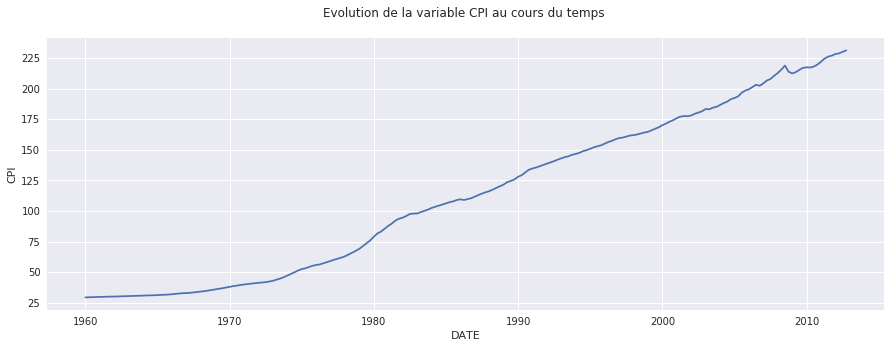

```python
plt.figure(figsize=(15,5))
sns.lineplot(df.DATE, df.CPI, data=df)
plt.title("Evolution de la variable CPI au cours du temps \n")
plt.show()
```

> La courbe ressemble à une **droite**, nous allons donc choisir une **méthode de régression linéaire**.

```python
data = {'t':[x for x in range(0, len(df.DATE))]}
X = pd.DataFrame(data)
X = sm.add_constant(X)
y = df[['CPI']]

model = sm.OLS(y,X)
results = model.fit()
o1 = results.resid
```

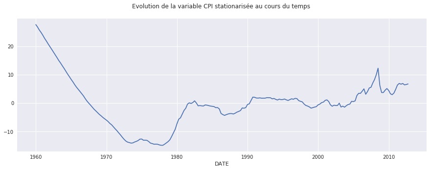

```python
plt.figure(figsize=(15,5))
sns.lineplot(df.DATE, o1, data=df)
plt.title("Evolution de la variable CPI stationarisée au cours du temps \n")
plt.show()
```

### **Question 3 :**

Stationnariser la série de CPI en utilisant un moyenne mobile centrée 5x5.

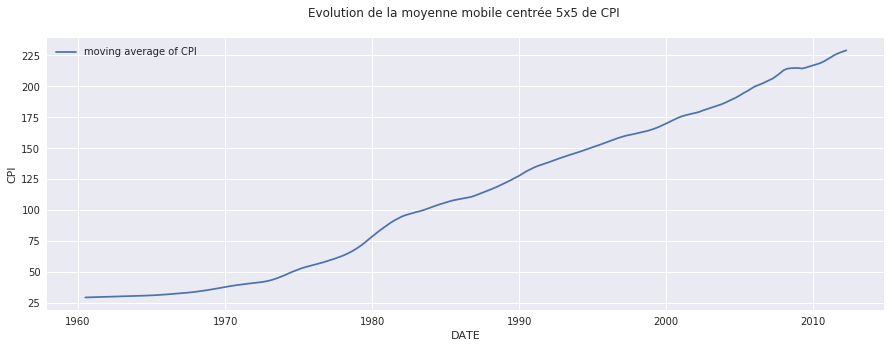

```python
mobile_mean = df.CPI.rolling(window=5, center=True).mean()

plt.figure(figsize=(15,5))
sns.lineplot(df.DATE, mobile_mean, data=df, label='moving average of CPI')
plt.title("Evolution de la moyenne mobile centrée 5x5 de CPI \n")
plt.legend()
plt.show()
```

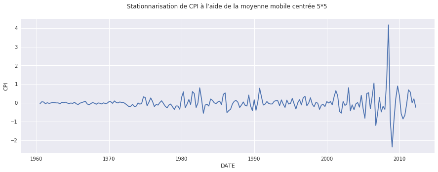

```python
o2 = df.CPI - mobile_mean

plt.figure(figsize=(15,5))
sns.lineplot(df.DATE, o2, data=df)
plt.title("Stationnarisation de CPI à l'aide de la moyenne mobile centrée 5*5 \n")
plt.show()
```

> En stationnarisant `CPI` avec la méthode de la moyenne mobile centrée 5x5, on est en mesure d'identifier des pics significatifs dans le temps. Ainsi, la crise financière de 2008 est clairement identifiable sur ce graphe et montre une chute brutale de la `CPI`.

### **Question 4 :**

Calculer `inf`, le taux d’inflation, à partir de la variable `CPI`. Faire un graphique dans le temps de `inf`. Commentez.

> La variable `CPI` correspond à l'index des prix à la consommation.

> Nous allons partir avec la formule de l'inflation donnée par : $$ \textit{inf(t)} = \frac { \textit{CPI(t)} - \textit{CPI(t-1)} } { \textit{CPI(t-1)} } $$

```python
df['inf'] = df['CPI'].pct_change()
df = df.dropna()
```

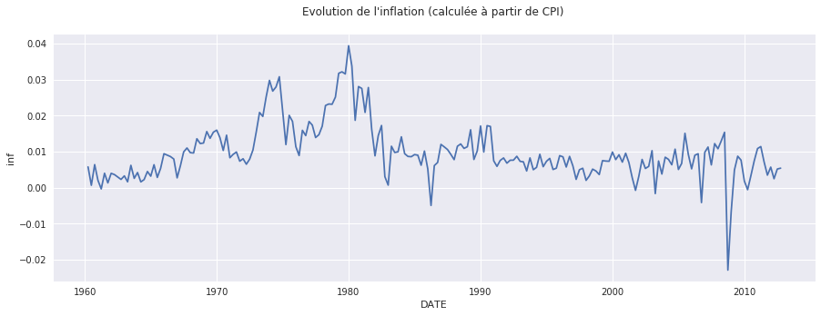

```python
plt.figure(figsize=(15,5))
sns.lineplot(df.DATE, df.inf, data=df)
#sns.regplot(pd.to_numeric(df.DATE), df.inf, data=df, fit_reg=True)
plt.title("Evolution de l'inflation (calculée à partir de CPI) \n")
plt.show()
```

> On constate une **inflation maîtrisée de 1960 à 1973**, puis on voit les **effets des 2 chocs pétroliers en 1974 et 1979** où l'inflation atteint des **taux de 3% voire 4%**. Elle se **stabilise ensuite entre 1990 et 2008**. S'ensuit une **déflation sur la période de crise financière de 2008**.

### **Question 5 :**

Interpréter l'autocorrélogramme et l'autocorrélogramme partiel de `inf`. Quelle est la différence entre ces deux graphiques ?

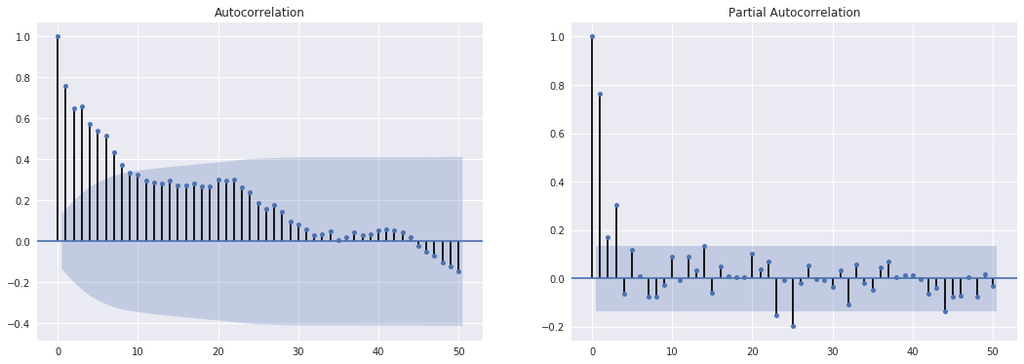

```python
fig, axes = plt.subplots(1, 2, figsize=(18,6))

fig = plot_acf(df.inf, lags=50, ax=axes[0])
fig = plot_pacf(df.inf, lags=50, ax=axes[1])
```

> L'autocorrélogramme indique que l'autocorrélation diminue avec le temps comme dans un processus *ARMA(p,q)*. La décroissance est en revanche plutôt lente, là où des séries stationnaires affichent généralement une nette décroissance exponentielle.

> L'autocorrélogramme partiel oscille autour de 0 comme dans un processus de type Moving Average *MA(0)*. Il est donc carractéristique d'un modèle auto-régressif. Nous constatons également que les 3-4 premiers coefficients sont les seuls significatifs avec un pic autour de 25 trimestres caractérisant des cycles de 6 ans.

> Il existe donc une influence non-négligeable du passé pour la détermination des valeurs présentes et on peut supposer que **la série n'est pas stationnaire**.

#### **Rappels :**

> L'autocorrélogramme donne l'influence d'une série à un temps $t-k$ dans le passé sur la valeur de la série au temps $t$, indépendemment du reste des observations.

> L'autocorrélogramme partiel réalise la régression de la valeur présente sur toutes les valeurs passées jusqu'au temps $t-k$. Ainsi, on identifie les effets joints des différentes périodes passées.

### **Question 6 :**

Quelle est la différence entre la stationnarité et l'ergodicité ? Pourquoi a-t-on besoin de ces deux conditions. Expliquez le terme "spurious regression".

#### **Stationnarité :**

> On dit qu'un processus est stationnaire si ces caractéristiques statistiques ne varient pas le long du temps. On peut distinguer deux types de stationnarités :
> - **Stationnarité au sens strict** : pour toute valeur de $N$, la caractérisation d'ordre $N$ du processus considéré est invariante par rapport à une translation sur l'axe du temps.
> - **Stationnarité au sens large** : la moyenne du processus aléatoire considéré est constante et sa fonction d'autocovariance ne dépend pas de l'origine du temps.

#### **Ergodicité :**

> L'ergodicité est un processus par lequel on oublie les conditions initiales. L'autocorrélation d'ordre $k$ tend alors vers $0$ lorsque $k$ tend vers $+\infty$. On dira qu'un processus stationnaire est ergodique lorsqu'il est possible de calculer l'ensemble de ses caractéristiques (moyenne, variance, fonction d'autocorrélation) à partir d'une seule trajectoire du processus, c'est-à-dire à partir d'une observation du processus.

#### **Stationnarité vs ergodicité :**

> Considérons un processus stochastique $X(n)$, $n$ étant entier. Pur calculer la moyenne de $X(1)$, on peut procéder de deux façons :
> - Soit en prenant plusieurs réalisations de ce processus, qui nous donneront donc chacune une valeur pour $x(1)$. Il suffira alors de faire la moyenne de ces valeurs.
> - Soit en prenant un seul processus et en faisant la moyenne de $X(1)$, $X(2)$,..., $X(n)$. Dans certains cas, les deux résultats coïncideront et on pourra parler de processus ergodique.

> L'ergodicité et la stationnarité sont des conditions nécessaires pour appliquer le **théorème d'ergodicité qui garantit que la moyenne des valeurs des observations tend vers l'espérance de la série**. Autrement dit, on s'assure que la série ne diverge pas de son espérance.

#### **Spurious regression :**

> Le terme "*spurious regression*" ou regression fallacieuse renvoit au fait que deux variables peuvent être corrélées sans qu'aucun lien de causalité n'existe ou soit établi entre ces variables. Il en résulte une situation dans laquelle la réalisation d'une régression sur une série temporelle non stationnaire engendrera des résultats erronés, faisant croire à une relation entre les variables alors qu'il n'y en a pas.

### **Question 7 :**

Faire le test Augmented Dickey Fuller pour `inf` en utilisant le critère AIC pour déterminer le nombre de lags à inclure. Commenter.

> Le test de Dickey-Fuller augmenté peut être utilisé pour tester une racine unitaire dans un processus univarié en présence d'une corrélation en série.

> On utilise la fonction `adfuller` de `statsmodels` pour réaliser ce test, avec le paramètre *autolag="AIC"* pour laisser l'algorithme déterminer le nombre de lags à inclure.

```python
adf_inf_aic = adfuller(df.inf, autolag="AIC")
print(adf_inf_aic)
```

```
(-2.919055814337061, 0.04317651687156625, 2, 208, {'1%': -3.4621857592784546, '5%': -2.875537986778846, '10%': -2.574231080806213}, -1519.2580655612676)
```

> Nous obtenons le résultat suivant:
> - Nombre de lags utilisés : **2**
> - Statistique de test, adf = **-2.92**
> - p-value = **0.043**
> - Nombre d'observations utilisées = **208**
> - Valeurs critiques pour le test statistique, à hauteur de :
>   - 1% : **-3.46**
>   - 5% : **-2.88**
>   - 10% : **-2.57**

> Ainsi, la p-valeur nous permet de rejeter l'hypothèse nulle de marche aléatoire, ce qui nous permet de conclure sur la stationnarité de la série avec un nombre de lags de 2.

### **Question 8 :**

Proposer une modélisation AR(p) de `inf`, en utilisant tous les outils vus au cours.

> On définit un modèle autorégressif $\textit{ARMA}(p,0)$ et on fait varier $p$ de $1$ à $10$. La sélection se base sur les critères AIC et BIC.

```python
AIC = []
BIC = []

for p in range(1, 11):
    model = ARMA(df.inf, order=(p,0))
    model_fit = model.fit()
    AIC.append(model_fit.aic)
    BIC.append(model_fit.bic)
```

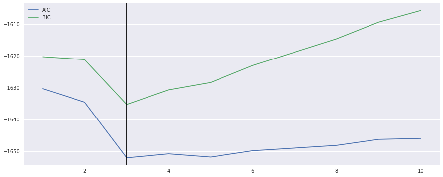

```
Lag optimal selon le critère BIC: 3
Lag optimal selon le critère AIC: 3
```

```python
plt.figure(figsize=(15, 6))
sns.lineplot(range(1, 11), AIC, label="AIC")
sns.lineplot(range(1, 11), BIC, label='BIC')
plt.axvline(3, c='black')
plt.legend()
plt.show()

print("Lag optimal selon le critère BIC: {:d}".format(np.argmin(BIC) + 1))
print("Lag optimal selon le critère AIC: {:d}".format(np.argmin(AIC) + 1))
```

> Les 2 critères, AIC et BIC, proposent $p=3$ comme optimisation.

> Etudions maintenant la performance en prédiction du modèle.

```python
df.inf = df.inf*100
```

```python
predictions = list()
history = [x for x in df.inf]

for t in range(len(df.inf)):
	model = ARMA(history, order=(3,0))
	model_fit = model.fit()
	output = model_fit.forecast()
	y_pred = output[0]
	predictions.append(y_pred)
	obs = df.inf.iloc[t]
	history.append(obs)
```

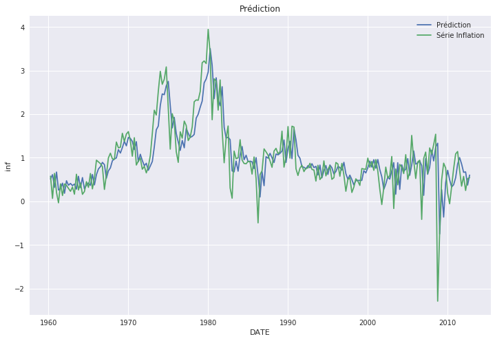

```python
plt.figure(figsize=(12,8))
plt.plot(df.DATE, predictions, label="Prédiction")
sns.lineplot(df.DATE, df.inf, data=df, label='Série Inflation')
plt.title("Prédiction")
plt.legend()
plt.show()
```

```python
print('Lag: %s' % model_fit.k_ar)
print('Coefficients: %s' % model_fit.params)
```

```
Lag: 3
Coefficients: [ 0.96293488  0.57949963 -0.01686036  0.29775061]
```

> Nous pouvons donc proposer un modèle AR(3) pour `inf`.

### **Question 9 :**

Estimer le modèle de la courbe de Philips qui explique le taux de chômage (`Unemp`) en fonction du taux d’inflation courant et une constante.

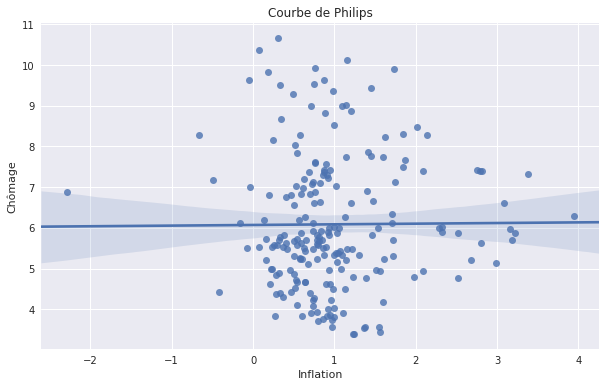

```python
plt.figure(figsize=(10,6))
sns.regplot(df.inf, df.Unemp, data=df, order=1, fit_reg=True)
plt.title("Courbe de Philips")
plt.xlabel("Inflation")
plt.ylabel("Chômage")
plt.show()
```

### **Question 10 :**

Tester l’autocorrélation des erreurs.

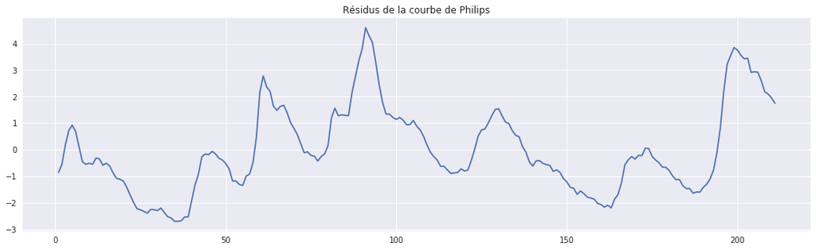

```python
X = sm.add_constant(df.inf)

model = sm.OLS(df.Unemp, X)
results = model.fit()
u = results.resid

plt.figure(figsize=(18,5))
plt.plot(u)
plt.title("Résidus de la courbe de Philips")
plt.show()
```

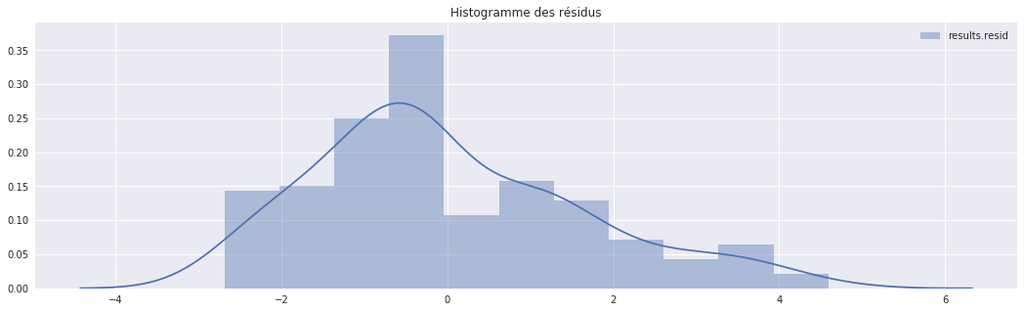

```python
plt.figure(figsize=(18,5))
sns.distplot(u, norm_hist=True, label='results.resid')
plt.title("Histogramme des résidus")
plt.legend()
plt.show()
```

> On affiche l'autocorrélogramme et l'autocorrélogramme partiel :

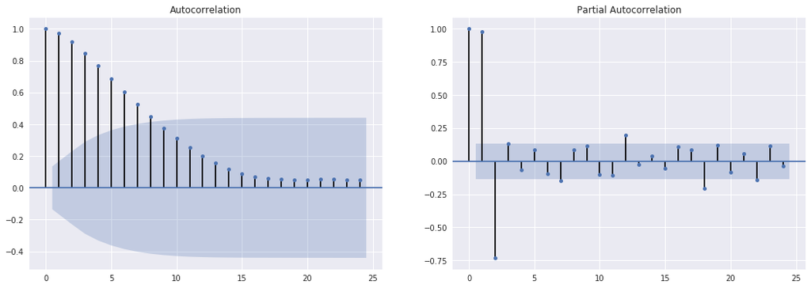

```python
fig, axes = plt.subplots(1, 2, figsize=(18,6))

fig = plot_acf(u, ax=axes[0])
fig = plot_pacf(u, ax=axes[1])
```

### **Question 11 :**

Corriger l’autocorrélation des erreurs par la méthode vue en cours.

> On a :
> $$ u_t = \rho u_{t-1} + e_t $$
> $$ y_t = \beta_0 + \beta_1 X_t + u_t \text{ et } y_{t-1} = \beta_0 + \beta_1 X_{t-1} + u_{t-1} $$

> On pose :
> $$ \tilde{y}_t = y_t - \rho y_{t-1} \text{ et } \tilde{X}_t = X_t - \rho X_{t-1} $$

> Afin de corriger l'autocorrélation, on peut estimer un nouveau modèle égal à :
> $$ \tilde{y}_t = (1-\rho) \beta_0 + \beta_1 \tilde{X}_t + \epsilon_t $$

#### **On commence par calculer $ \rho $**

```python
ut = u[1:].reset_index(drop='True')
ut_1 = u[:-1].reset_index(drop='True')
```

```python
model = sm.OLS(ut, ut_1)
results = model.fit()
rho = results.params[0]
print(rho)
```

```
0.9799237799707919
```

#### **Calcul du modèle tilde**

```python
X = df[['inf']]
y = df[['Unemp']]

Xtilde = (X - rho * X.shift(1)).dropna().reset_index(drop='True')
ytilde = (y - rho * y.shift(1)).dropna().reset_index(drop='True')

Xtilde = sm.add_constant(Xtilde)

model = sm.OLS(ytilde, Xtilde)
results = model.fit()
u = results.resid
```

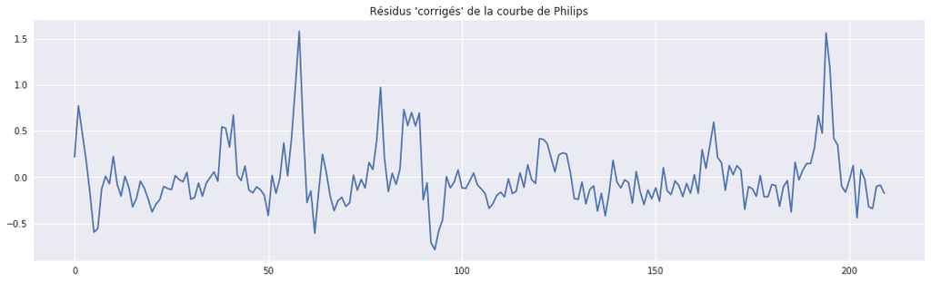

```python
plt.figure(figsize=(18,5))
plt.plot(u)
plt.title("Résidus 'corrigés' de la courbe de Philips")
plt.show()
```

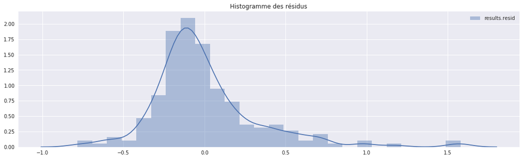

```python
plt.figure(figsize=(18,5))
sns.distplot(u, norm_hist=True, label='results.resid')
plt.title("Histogramme des résidus")
plt.legend()
plt.show()
```

> L'amplitude des résidus est plus faible et leur distribution est beaucoup plus concentrée autour de $0$.

> Affichons l'autocorrélogramme et l'autocorrélogramme partiel.

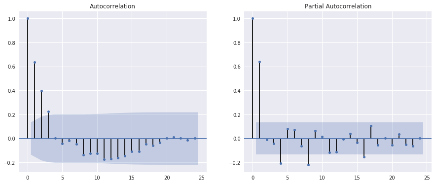

```python
fig, axes = plt.subplots(1, 2, figsize=(15,6))

fig = plot_acf(u, ax=axes[0])
fig = plot_pacf(u, ax=axes[1])
```

> L'autocorrélation des erreurs a été en grande partie diminuée. On gardera donc ces variables pour la suite.

### **Question 12 :**

Tester la stabilité de la relation chômage-inflation sur deux sous-périodes de taille identique.

> La longueur de la série étudiée étant de 210 observations, nous couperons notre échantillon en deux morceaux avec 105 observations chacun.

```python
model = sm.OLS(ytilde[:105], Xtilde[:105])
results = model.fit()
print(results.summary())
```

```
                            OLS Regression Results
==============================================================================
Dep. Variable:                  Unemp   R-squared:                       0.102
Model:                            OLS   Adj. R-squared:                  0.093
Method:                 Least Squares   F-statistic:                     11.70
Date:                Sat, 11 Apr 2020   Prob (F-statistic):           0.000899
Time:                        12:46:32   Log-Likelihood:                -41.619
No. Observations:                 105   AIC:                             87.24
Df Residuals:                     103   BIC:                             92.55
Df Model:                           1
Covariance Type:            nonrobust
==============================================================================
                 coef    std err          t      P>|t|      [0.025      0.975]
------------------------------------------------------------------------------
const          0.1463      0.035      4.123      0.000       0.076       0.217
inf           -0.2576      0.075     -3.420      0.001      -0.407      -0.108
==============================================================================
Omnibus:                       24.863   Durbin-Watson:                   0.822
Prob(Omnibus):                  0.000   Jarque-Bera (JB):               41.082
Skew:                           1.032   Prob(JB):                     1.20e-09
Kurtosis:                       5.265   Cond. No.                         2.13
==============================================================================

Warnings:
[1] Standard Errors assume that the covariance matrix of the errors is correctly specified.
```

```python
model = sm.OLS(ytilde[105:], Xtilde[105:])
results = model.fit()
print(results.summary())
```

```
                            OLS Regression Results
==============================================================================
Dep. Variable:                  Unemp   R-squared:                       0.000
Model:                            OLS   Adj. R-squared:                 -0.010
Method:                 Least Squares   F-statistic:                  0.007169
Date:                Sat, 11 Apr 2020   Prob (F-statistic):              0.933
Time:                        12:46:32   Log-Likelihood:                -18.096
No. Observations:                 105   AIC:                             40.19
Df Residuals:                     103   BIC:                             45.50
Df Model:                           1
Covariance Type:            nonrobust
==============================================================================
                 coef    std err          t      P>|t|      [0.025      0.975]
------------------------------------------------------------------------------
const          0.1290      0.028      4.554      0.000       0.073       0.185
inf            0.0041      0.049      0.085      0.933      -0.093       0.101
==============================================================================
Omnibus:                       60.865   Durbin-Watson:                   0.558
Prob(Omnibus):                  0.000   Jarque-Bera (JB):              230.422
Skew:                           2.034   Prob(JB):                     9.21e-51
Kurtosis:                       9.010   Cond. No.                         1.72
==============================================================================

Warnings:
[1] Standard Errors assume that the covariance matrix of the errors is correctly specified.
```

### **Question 13 :**

Faites les tests changement de structure de Chow et détecter le point de rupture.

> Dans l'analyse des modèles temporelles, la régression sur l'ensemble de la période est différente de la régression sur les sous-périodes. Le but du test de Chow est donc de détecter ce changement de structure.

> Dans le principe, onestime 3 modèles de régressions :
> - **Une régression non contrainte** : sur l'ensemble de l'échantillon
> - **Deux régressions contraintes** : sur les deux sous-échantillons définis.

> L'hypothèse nulle du test de Chow nous dit que les coefficients de régressions sont égaux entre les deux sous périodes considérés.

```python
# TEST DE CHOW

# Modèle non contraint
n,p = Xtilde.shape
model = sm.OLS(ytilde, Xtilde) # la constante est déjà dans Xtilde
results = model.fit()
u = results.resid
SSR0 = u.T@u

idx = 105 # Moitie de l'echantillon

# Modèle contraint : première sous période
model1 = sm.OLS(ytilde[:idx], Xtilde[:idx]) # la constante est déjà dans Xtilde
results1 = model1.fit()
u1 = results1.resid
SSR1 = u1.T @ u1

# Modèle contraint  : deuxième sous période
model2 = sm.OLS(ytilde[idx:], Xtilde[idx:]) # la constante est déjà dans Xtilde
results2 = model2.fit()
u2 = results2.resid
SSR2 = u2.T @ u2

# Stat de test
# 2 paramètres à estimer dans le modèle non contraint
# n-2*2 degrés de liberté

F = ((SSR0 - (SSR1 + SSR2))/(SSR1 + SSR2)) * (n-2*p)/p
p_value = f.sf(F, p, n-2*p)

print("p-value : %f " %p_value)
print("Test de Fisher  : %f" %F)
```

```
p-value : 0.012480
Test de Fisher  : 4.478281
```

> La p-valeur est inférieure au seuil de 5%. On rejette donc l'hypothèse de stabilité entre les deux périodes pour la séparation que nous avons effectuée.

> Pour détecter le point de rupture, nous allons calculer la statistique de test et la p-valeur en faisant varier l'indice de séparation des 2 périodes.

```python
def chow_test(i):

    # Modèle contraint : première sous période
    model1 = sm.OLS(ytilde[:i], Xtilde[:i]) # la constante est déjà dans Xtilde
    results1 = model1.fit()
    u1 = results1.resid
    SSR1 = u1.T @ u1

    # Modèle contraint  : deuxième sous période
    model2 = sm.OLS(ytilde[i:], Xtilde[i:]) # la constante est déjà dans Xtilde
    results2 = model2.fit()
    u2 = results2.resid
    SSR2 = u2.T @ u2

    # Stat de test
    # 2 paramètres à estimer dans le modèle non contraint
    # n-2*2 degrés de liberté

    F = ((SSR0 - (SSR1 + SSR2))/(SSR1 + SSR2)) * (n-2*p)/p
    p_value = f.sf(F, p, n-2*p)

    #print("p-value : %f " %p_value)
    #print("Test de Fisher  : %f" %F)

    return F, p_value
```

```python
# Modèle non-contraint
n,p = Xtilde.shape
model = sm.OLS(ytilde, Xtilde) # la constante est déjà dans Xtilde
results = model.fit()
u = results.resid
SSR0 = u.T@u

Fs = []
p_values = []

# On parcourt l'intervale avec un taux de trim de 15% aux extrémités
gauche = int(0.15*len(ytilde))
droite = int(0.85*len(ytilde))

for i in np.arange(gauche, droite):
    F, p_value = chow_test(i)
    Fs.append(F)
    p_values.append(p_value)
```

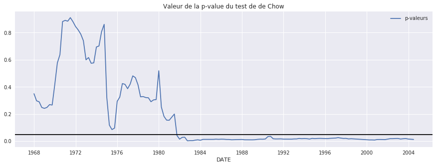

```python
plt.figure(figsize=(15,5))
sns.lineplot(df.DATE[gauche:droite], p_values, label='p-valeurs')
plt.axhline(0.05, color="black")
plt.title("Valeur de la p-value du test de de Chow")
plt.legend()
plt.show()
```

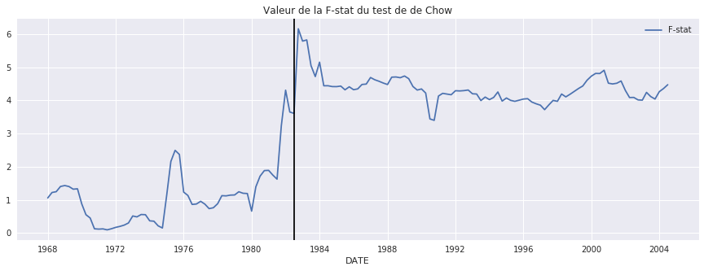

```python
plt.figure(figsize=(15,5))
sns.lineplot(df.DATE[gauche:droite], Fs, label='F-stat')
plt.axvline(df.DATE[np.argmax(Fs) + int(0.15*len(Xtilde))], color='black')
plt.title("Valeur de la F-stat du test de de Chow")
plt.legend()
plt.show()
```

```python
# Point de rupture
print('La valeur de la stat de Fischer au point de rupture est de : ' + str(Fs[np.argmax(Fs)]))
```

```
La valeur de la stat de Fischer au point de rupture est de : 6.158078722293731
```

```python
# La date correspondante a ce point de rupture est :
tmp = df.DATE.iloc[np.argmax(Fs) + int(0.15*len(Xtilde))]
print('La date correspondante a ce point de rupture est : ' + str(tmp))
```

```
La date correspondante a ce point de rupture est : 1982-10-01 00:00:00
```

> Le point de rupture correspond à la **fin du choc pétrolier des années 80**, il est donc logique d'avoir identifé ici notre point de rupture.

### **Question 14 :**

Estimer la courbe de Philips en supprimant l'inflation courante des variables explicatives mais en ajoutant les délais d’ordre 1, 2, 3 et 4 de l’inflation et du chômage.

```python
z = pd.DataFrame()

z[['DATE']] = df[['DATE']]
z[['Unemp']] = df[['Unemp']]
z[['inf']] = df[['inf']]
z[["Unemp_1", "inf_1"]] = df[["Unemp", "inf"]].shift(1)
z[["Unemp_2", "inf_2"]] = df[["Unemp", "inf"]].shift(2)
z[["Unemp_3", "inf_3"]] = df[["Unemp", "inf"]].shift(3)
z[["Unemp_4", "inf_4"]] = df[["Unemp", "inf"]].shift(4)

z
```

|  | DATE | Unemp | inf | Unemp_1 | inf_1 | Unemp_2 | inf_2 | Unemp_3 | inf_3 | Unemp_4 | inf_4 |
| --- | --- | --- | --- | --- | --- | --- | --- | --- | --- | --- | --- |
| 1 | 1960-04-01 | 5.23 | 0.578231 | NaN | NaN | NaN | NaN | NaN | NaN | NaN | NaN |
| 2 | 1960-07-01 | 5.53 | 0.067636 | 5.23 | 0.578231 | NaN | NaN | NaN | NaN | NaN | NaN |
| 3 | 1960-10-01 | 6.27 | 0.642109 | 5.53 | 0.067636 | 5.23 | 0.578231 | NaN | NaN | NaN | NaN |
| 4 | 1961-01-01 | 6.80 | 0.201478 | 6.27 | 0.642109 | 5.53 | 0.067636 | 5.23 | 0.578231 | NaN | NaN |
| 5 | 1961-04-01 | 7.00 | -0.033512 | 6.80 | 0.201478 | 6.27 | 0.642109 | 5.53 | 0.067636 | 5.23 | 0.578231 |
| ... | ... | ... | ... | ... | ... | ... | ... | ... | ... | ... | ... |
| 207 | 2011-10-01 | 8.67 | 0.349279 | 9.00 | 0.716926 | 9.03 | 1.143990 | 9.00 | 1.088144 | 9.53 | 0.747672 |
| 208 | 2012-01-01 | 8.27 | 0.572763 | 8.67 | 0.349279 | 9.00 | 0.716926 | 9.03 | 1.143990 | 9.00 | 1.088144 |
| 209 | 2012-04-01 | 8.17 | 0.249704 | 8.27 | 0.572763 | 8.67 | 0.349279 | 9.00 | 0.716926 | 9.03 | 1.143990 |
| 210 | 2012-07-01 | 8.03 | 0.520014 | 8.17 | 0.249704 | 8.27 | 0.572763 | 8.67 | 0.349279 | 9.00 | 0.716926 |
| 211 | 2012-10-01 | 7.83 | 0.543407 | 8.03 | 0.520014 | 8.17 | 0.249704 | 8.27 | 0.572763 | 8.67 | 0.349279 |

211 rows × 11 columns

```python
X_1 = z[['Unemp_1', 'Unemp_2', 'Unemp_3', 'Unemp_4', 'inf_1', 'inf_2', 'inf_3', 'inf_4']].iloc[4:]
X_1 = sm.add_constant(X_1)
y = df['Unemp'][4:]

model_1 = sm.OLS(y,X_1)
results_1 = model_1.fit()
u_1 = results_1.resid
print(results_1.summary())
```

```
                            OLS Regression Results
==============================================================================
Dep. Variable:                  Unemp   R-squared:                       0.979
Model:                            OLS   Adj. R-squared:                  0.978
Method:                 Least Squares   F-statistic:                     1145.
Date:                Sat, 11 Apr 2020   Prob (F-statistic):          2.80e-161
Time:                        12:46:35   Log-Likelihood:                 4.6497
No. Observations:                 207   AIC:                             8.701
Df Residuals:                     198   BIC:                             38.70
Df Model:                           8
Covariance Type:            nonrobust
==============================================================================
                 coef    std err          t      P>|t|      [0.025      0.975]
------------------------------------------------------------------------------
const          0.1457      0.072      2.014      0.045       0.003       0.288
Unemp_1        1.5937      0.071     22.383      0.000       1.453       1.734
Unemp_2       -0.6472      0.134     -4.832      0.000      -0.911      -0.383
Unemp_3        0.0222      0.135      0.164      0.870      -0.245       0.289
Unemp_4       -0.0080      0.070     -0.114      0.910      -0.146       0.130
inf_1          0.0311      0.038      0.827      0.409      -0.043       0.105
inf_2         -0.0236      0.041     -0.577      0.565      -0.104       0.057
inf_3          0.0689      0.040      1.729      0.085      -0.010       0.148
inf_4          0.0163      0.038      0.435      0.664      -0.058       0.090
==============================================================================
Omnibus:                       29.127   Durbin-Watson:                   1.997
Prob(Omnibus):                  0.000   Jarque-Bera (JB):               68.886
Skew:                           0.625   Prob(JB):                     1.10e-15
Kurtosis:                       5.534   Cond. No.                         143.
==============================================================================

Warnings:
[1] Standard Errors assume that the covariance matrix of the errors is correctly specified.
```

Faire le test de Granger de non causalité de l’inflation sur le chômage. Donnez la p-valeur.

> L'hypothèse nulle pour les tests de causalité de Granger est que l'inflation n'a pas de lien de causalité sur le chômage. Nous rejetterons cette hypothèse nulle si les p-valeurs sont inférieures au seuil désiré (5% dans notre cas).

```python
granger(df[['Unemp', 'inf']], 5)
```

```
Granger Causality
number of lags (no zero) 1
ssr based F test:         F=8.9875  , p=0.0031  , df_denom=207, df_num=1
ssr based chi2 test:   chi2=9.1177  , p=0.0025  , df=1
likelihood ratio test: chi2=8.9254  , p=0.0028  , df=1
parameter F test:         F=8.9875  , p=0.0031  , df_denom=207, df_num=1

Granger Causality
number of lags (no zero) 2
ssr based F test:         F=4.3146  , p=0.0146  , df_denom=204, df_num=2
ssr based chi2 test:   chi2=8.8406  , p=0.0120  , df=2
likelihood ratio test: chi2=8.6587  , p=0.0132  , df=2
parameter F test:         F=4.3146  , p=0.0146  , df_denom=204, df_num=2

Granger Causality
number of lags (no zero) 3
ssr based F test:         F=5.0265  , p=0.0022  , df_denom=201, df_num=3
ssr based chi2 test:   chi2=15.6045 , p=0.0014  , df=3
likelihood ratio test: chi2=15.0469 , p=0.0018  , df=3
parameter F test:         F=5.0265  , p=0.0022  , df_denom=201, df_num=3

Granger Causality
number of lags (no zero) 4
ssr based F test:         F=3.7967  , p=0.0054  , df_denom=198, df_num=4
ssr based chi2 test:   chi2=15.8771 , p=0.0032  , df=4
likelihood ratio test: chi2=15.2977 , p=0.0041  , df=4
parameter F test:         F=3.7967  , p=0.0054  , df_denom=198, df_num=4

Granger Causality
number of lags (no zero) 5
ssr based F test:         F=2.6928  , p=0.0223  , df_denom=195, df_num=5
ssr based chi2 test:   chi2=14.2236 , p=0.0143  , df=5
likelihood ratio test: chi2=13.7540 , p=0.0172  , df=5
parameter F test:         F=2.6928  , p=0.0223  , df_denom=195, df_num=5
```

[output not shown]

> Toutes nos p-valeurs sont inférieures à 5%, **nous rejetons donc l'hypothèse que l'inflation n'a pas de lien de causalité avec le chômage**.

### **Question 15 :**

Représentez graphiquement les délais distribués et commentez.

> Un délai distribué peut-être exprimé comme : $$ y_t = \alpha_0 + \delta_0 z_t + \delta_1 z_{t-1} + \delta_2 z_{t-2} + \delta_3 z_{t-3} + \delta_4 z_{t-4} + u_t $$

```python
cols_to_keep = ['inf', 'inf_1', 'inf_2', 'inf_3', 'inf_4']

X_2 = z[cols_to_keep].iloc[4:]
X_2 = sm.add_constant(X_2)
y = df['Unemp'][4:]

model_2 = sm.OLS(y,X_2)
results_2 = model_2.fit()
u_2 = results_2.resid

print(results_2.summary())
```

```
                            OLS Regression Results
==============================================================================
Dep. Variable:                  Unemp   R-squared:                       0.104
Model:                            OLS   Adj. R-squared:                  0.081
Method:                 Least Squares   F-statistic:                     4.650
Date:                Sat, 11 Apr 2020   Prob (F-statistic):           0.000487
Time:                        12:46:35   Log-Likelihood:                -383.05
No. Observations:                 207   AIC:                             778.1
Df Residuals:                     201   BIC:                             798.1
Df Model:                           5
Covariance Type:            nonrobust
==============================================================================
                 coef    std err          t      P>|t|      [0.025      0.975]
------------------------------------------------------------------------------
const          5.7414      0.195     29.504      0.000       5.358       6.125
inf           -0.3935      0.231     -1.703      0.090      -0.849       0.062
inf_1         -0.2411      0.269     -0.896      0.371      -0.772       0.289
inf_2          0.0243      0.257      0.094      0.925      -0.483       0.531
inf_3          0.2208      0.268      0.825      0.411      -0.307       0.749
inf_4          0.7396      0.230      3.218      0.002       0.286       1.193
==============================================================================
Omnibus:                       35.345   Durbin-Watson:                   0.106
Prob(Omnibus):                  0.000   Jarque-Bera (JB):               51.968
Skew:                           0.984   Prob(JB):                     5.19e-12
Kurtosis:                       4.466   Cond. No.                         9.75
==============================================================================

Warnings:
[1] Standard Errors assume that the covariance matrix of the errors is correctly specified.
```

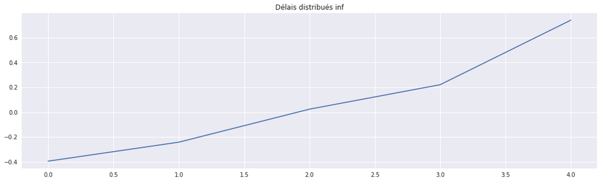

```python
plt.figure(figsize=(18,5))
plt.plot(results_2.params[1:].values)
plt.title("Délais distribués inf")
plt.show()
```

Calculer l’impact à long de terme de l’inflation sur le chômage.

> L'effet à long terme est donné par : $$ \delta_0 + \delta_1 + \delta_2 + \delta_3 + ... $$

```python
results_2.params[1:].sum()
```

```
0.3500658624599664
```